# Lab 6: Two-Sample t-Test

Authors

Yeon Soon Shin

Anjali Thapar

Dustin Albert

Kevin P. McIntyre

# 1 Two-Sample t-Test

> This lab is adapted from Kevin P. McIntyre’s [OSL Open Stats Lab](https://sites.google.com/view/openstatslab/home/regression-activities?pli=1&authuser=0).

We will continue to explore the data from Tworek and Cimpian (2016), where they investigated people’s bias to prefer explanations that are based on inherent properties over extrinsic explanations.

## 1.1 Preliminaries

```r
library(tidyverse)  # for data wrangling and visualization
library(psych)      # for describe() and scoreItems()
library(janitor)    # for frequency and contingency tables
library(broom)      # for tidy t-test output
library(papaja)     # for APA style output
library(car)        # for leveneTest()
library(lsr)        # for cohensD()
library(BrailleR)   # for accessibility
GoBlind()
```

## 1.2 Within-Subject Design

In the previous lab, we conducted a one-sample t-test to see if there was a difference in endorsement of inherent vs. extrinsic explanations. The same participants were asked to rate their agreement with both types of explanations, so the data are paired. In this case, we can also use a paired samples t-test to test the same hypothesis.

### 1.2.1 Null Hypothesis and Alternative Hypothesis

The null hypothesis is that the average endorsement is the same for inherent and extrinsic explanations. For a two-tailed test, the alternative hypothesis is that the average endorsement is different for inherent and extrinsic explanations.

*H*<sub>0</sub> : *μ*<sub>inherent</sub> = *μ*<sub>extrinsic</sub> *H*<sub>1</sub> : *μ*<sub>inherent</sub> ≠ *μ*<sub>extrinsic</sub>

Put differently,

*H*<sub>0</sub> : *μ*<sub>Diff</sub> = 0 *H*<sub>1</sub> : *μ*<sub>Diff</sub> ≠ 0

### 1.2.2 Read in and clean the data

In study 2, there are four variables of interest: `diff`, `ihav`, `extav`, and `excluded`.

- `diff`: the difference between the average inherent and extrinsic scores
- `ihav`: the average inherent score
- `extav`: the average extrinsic score

```r
df <- read_csv('data/tworek2016_study2.csv') %>%
  filter(excluded == 0) %>% # filter in not excluded participants
  as_tibble() %>%
  select(diff, ihav, extav)

glimpse(df)
```

```
Rows: 112
Columns: 3
$ diff  <dbl> -0.1333333, 0.6666667, 5.0000000, 2.9333333, 0.5333333, 1.600000…
$ ihav  <dbl> 6.066667, 5.666667, 7.800000, 7.400000, 6.066667, 5.733333, 3.53…
$ extav <dbl> 6.200000, 5.000000, 2.800000, 4.466667, 5.533333, 4.133333, 7.80…
```

```r
describe(df) %>%
  apa_num() %>% # round the numbers to 2 decimal places
  knitr::kable()
```

|  | vars | n | mean | sd | median | trimmed | mad | min | max | range | skew | kurtosis | se |
| --- | --- | --- | --- | --- | --- | --- | --- | --- | --- | --- | --- | --- | --- |
| diff | 1 | 112.00 | 0.65 | 1.74 | 0.53 | 0.66 | 1.33 | -5.40 | 7.60 | 13.00 | -0.06 | 3.64 | 0.16 |
| ihav | 2 | 112.00 | 6.12 | 1.08 | 6.17 | 6.16 | 0.84 | 2.80 | 9.00 | 6.20 | -0.51 | 0.93 | 0.10 |
| extav | 3 | 112.00 | 5.47 | 1.16 | 5.57 | 5.47 | 0.94 | 1.40 | 8.67 | 7.27 | -0.23 | 0.78 | 0.11 |

### 1.2.3 Check Assumptions

#### 1.2.3.1 Normality

For the paired samples t-test, we will check the normality of the difference scores. Again, t-test is robust to moderate violations of normality, but we will still visualize the distribution of the data using a histogram and conduct the Shapiro-Wilk test for normality.

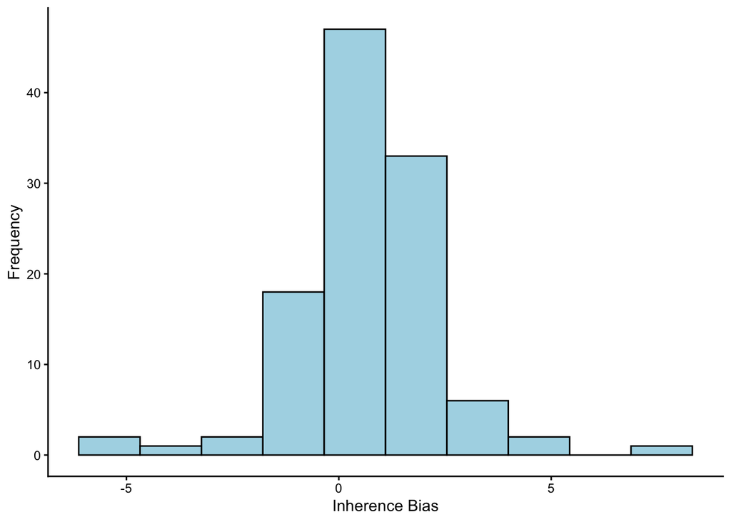

```
This is an untitled chart with no subtitle or caption.
It has x-axis 'Inherence Bias' with labels -5, 0 and 5.
It has y-axis 'Frequency' with labels 0, 10, 20, 30 and 40.
The chart is a bar chart with 10 vertical bars.
Bar 1 is centered at -5.4, and length is from 0 to 2.
Bar 2 is centered at -3.96, and length is from 0 to 1.
Bar 3 is centered at -2.51, and length is from 0 to 2.
Bar 4 is centered at -1.07, and length is from 0 to 18.
Bar 5 is centered at 0.38, and length is from 0 to 47.
Bar 6 is centered at 1.82, and length is from 0 to 33.
Bar 7 is centered at 3.27, and length is from 0 to 6.
Bar 8 is centered at 4.71, and length is from 0 to 2.
Bar 9 is centered at 6.16, and length is from 0 to 0.
Bar 10 is centered at 7.6, and length is from 0 to 1.
It has colour set to black.
It has fill set to very light greenish blue.
```

```r
df %>%
    ggplot(aes(x = diff)) +
    geom_histogram(bins = 10, color = "black", fill = "lightblue") +
    labs(x = "Inherence Bias", y = "Frequency") +
    theme_classic()
```

```r
res_shapiro <- shapiro.test(df$diff)

res_shapiro  %>%
  tidy() %>%
  mutate(
    across(where(is.numeric) & !p.value, ~ apa_num(.)),
    p.value = apa_p(p.value)
  ) %>%
  knitr::kable()
```

| statistic | p.value | method |
| --- | --- | --- |
| 0.93 | < .001 | Shapiro-Wilk normality test |

**NoteShapiro-Wilk Test Results**

*W* = 0.93, *p* < .001

### 1.2.4 Point plot of the means and confidence intervals

We will plot the data using a point plot of the mean differences and the 95% confidence intervals of the difference scores. The error bars can represent either the standard error of the mean or the 95% confidence interval. The convention is to use the 95% confidence interval for point plots, and the standard error of the mean for bar graphs. Here, we will use the 95% confidence interval.

```
This is an untitled chart with no subtitle or caption.
There is no x-axis.
It has y-axis 'Inherence Bias' with labels -5, 0 and 5.
It has 4 layers.
Layer 1 is 1 horizontal line as follows:
Line at y position 0.
Layer 1 has linetype set to dashed.
Layer 1 has colour set to black.
Layer 2 is a set of 1 big solid circle point of which about 100% can be seen.
The points are at:
(, 0.65)
Layer 2 has colour set to black.
Layer 2 has size set to 3.
Layer 3 is an errorbar graph that VI cannot process.
Layer 3 has width set to 0.2.
Layer 4 is a set of 112 big solid circle points of which about 100% can be seen.
Layer 4 has alpha set to 0.2.
Layer 4 has size set to 0.5.
```

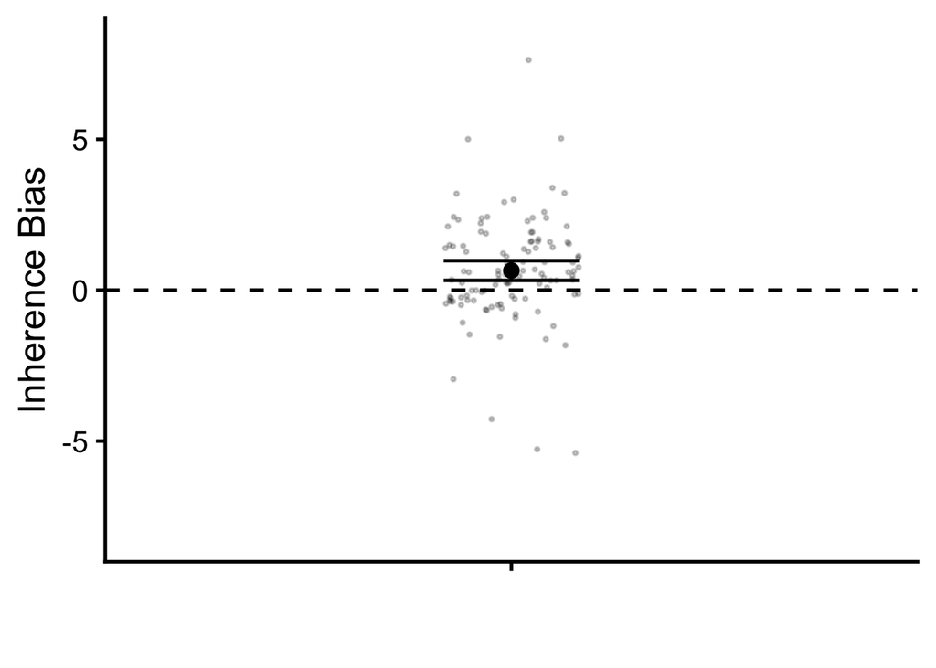

Figure 1: Mean of inherence bias (differences in endorsement of inherent vs. extrinsic explanations). Error bars represent 95% confidence intervals.

```r
df %>%
  ggplot(aes(x = "", y = diff)) +
  # horizontal line at y = 0
  geom_hline(yintercept = 0, linetype = "dashed", color = "black") +
  # mean per condition
  stat_summary(fun = mean, geom = "point", color = "black", size = 3) +
  # confidence interval per condition (bootstrap CI)
  stat_summary(fun.data = mean_cl_normal, geom = "errorbar", width = 0.2) +
  # overlay individual data points with jitter and transparency
  geom_point(position = position_jitter(width = 0.1), alpha = 0.2, size = 0.5) +
  # axis label
  labs(x = "", y = "Inherence Bias") +
  scale_y_continuous(expand = c(0, 0), limits = c(-9, 9))
```

### 1.2.5 Paired Samples t-Test

We conduct the paired-samples t-test on the inherent and extrinsic scores, or we can conduct the one-sample t-test on the difference scores. The results will be identical.

```r
res_paired_t <- t.test(df$ihav, df$extav,
                paired = TRUE,
                alternative = "two.sided")
res_paired_t %>%
  tidy() %>%
  mutate(
    across(where(is.numeric) & !p.value, ~ apa_num(.)),
    p.value = apa_p(p.value)
  ) %>%
  knitr::kable()
```

| estimate | statistic | p.value | parameter | conf.low | conf.high | method | alternative |
| --- | --- | --- | --- | --- | --- | --- | --- |
| 0.65 | 3.94 | < .001 | 111.00 | 0.32 | 0.97 | Paired t-test | two.sided |

```r
res_paired_t
```

```
    Paired t-test

data:  df$ihav and df$extav
t = 3.939, df = 111, p-value = 0.0001433
alternative hypothesis: true mean difference is not equal to 0
95 percent confidence interval:
 0.3221185 0.9743101
sample estimates:
mean difference
      0.6482143
```

Here’s the one-sample t-test version that you’ve already done in the previous lab:

```r
res_onesample_t <- t.test(df$diff,
                mu = 0,
                alternative = "two.sided")
res_onesample_t %>%
  tidy() %>%
  mutate(
    across(where(is.numeric) & !p.value, ~ apa_num(.)),
    p.value = apa_p(p.value)
  ) %>%
  knitr::kable()
```

| estimate | statistic | p.value | parameter | conf.low | conf.high | method | alternative |
| --- | --- | --- | --- | --- | --- | --- | --- |
| 0.65 | 3.94 | < .001 | 111.00 | 0.32 | 0.97 | One Sample t-test | two.sided |

```r
res_onesample_t
```

```
    One Sample t-test

data:  df$diff
t = 3.939, df = 111, p-value = 0.0001433
alternative hypothesis: true mean is not equal to 0
95 percent confidence interval:
 0.3221185 0.9743101
sample estimates:
mean of x
0.6482143
```

You can see that the results are identical, because whether the two means are the same is the same thing as asking whether the mean of the difference scores is 0.

**Notet-test Results**

- Paired samples t-test on the inherent and extrinsic scores: *M*<sub>*D*</sub> = 0.65, 95% CI $[0.32, 0.97]$, *t*(111) = 3.94, *p* < .001
- One sample t-test on the difference scores: *M* = 0.65, 95% CI $[0.32, 0.97]$, *t*(111) = 3.94, *p* < .001

### 1.2.6 Effect Size (Cohen’s d)

Effect size can be computed using Cohen’s d. For a paired samples t-test, we can compute Cohen’s d using the `cohensD()` function from the `lsr` package. The `method` argument is set to “paired” to indicate that the data are paired.

```r
d_paired <- cohensD(df$ihav, df$extav, method = "paired")
d_paired
```

```
[1] 0.3721972
```

**NoteCohen’s d**

Cohen’s d = 0.37

### 1.2.7 Write up the results

> Paired samples t-test was performed to compare inherence bias scores between inherent and extrinsic explanations. The results indicated that the mean inherence bias (*M*<sub>inherent</sub> = 6.12) was significantly higher than the mean extrinsic bias (*M*<sub>extrinsic</sub> = 5.47), *M*<sub>*D*</sub> = 0.65, 95% CI $[0.32, 0.97]$, *t*(111) = 3.94, *p* < .001, with a small effect size, d = 0.37 (see Figure 1). These results suggest that people have a small preference for inherent explanations over extrinsic explanations.

**TipPaired Samples t-test Write-Up Checklist**

- What type of test was performed (e.g., Paired samples t-test), to test what hypothesis?
- Which DV was tested?
- What was your sample mean in each condition?
  - *M*<sub>1</sub>
  - *M*<sub>2</sub>
- What was your estimate for the mean of difference scores between conditions?
  - *M*<sub>*D*</sub>
  - 95% CI<sub>*M*<sub>*D*</sub></sub>
- What are the results of the analysis?
  - Was the mean of one condition significantly higher or lower than the other condition? In which direction?
  - t statistic
  - degrees of freedom
  - p-value
- What was the practical significance of the results?
  - Small, medium, or large effect size?
  - Cohen’s d
- What do the statistical results mean in the context of the research question?
- If a figure is included, refer to it in the write up.

## 1.3 Between-Subject Design

In their study 4, Tworek and Cimpian (2016) investigated whether priming extrinsic explanations can reduce inherence bias. In this study, participants were randomly assigned to one of two conditions: the Anti-Inherence condition, where they were primed with extrinsic explanations, and the Control condition, where they were not primed. The dependent variable is the inherence bias score, which is the average of 15 items that measure people’s preference for inherent explanations over extrinsic explanations.

For this, we can conduct an independent samples t-test to see if there is a significant difference in the average inherence bias score between the two conditions.

### 1.3.1 Null Hypothesis and Alternative Hypothesis

The null hypothesis is that the average inherence bias score is the same for the Anti-Inherence and Control conditions. For a two-tailed test, the alternative hypothesis is that the average inherence bias score is different for the two conditions.

*H*<sub>0</sub> : *μ*<sub>Anti-Inherence</sub> = *μ*<sub>Control</sub> *H*<sub>1</sub> : *μ*<sub>Anti-Inherence</sub> ≠ *μ*<sub>Control</sub>

### 1.3.2 Read in and clean the data

`Condition` is a categorical variable with two levels: “Anti-Inherence” and “Control”.

```r
df <- read_csv('data/tworek2016_study4.csv') %>%
  filter(Excluded == 0) %>% # filter in not excluded participants
  as_tibble() %>%
  select(InherenceBias, Condition) %>%
  mutate(Condition = factor(Condition, levels = c("Anti-Inherence", "Control")))

glimpse(df)
```

```
Rows: 267
Columns: 2
$ InherenceBias <dbl> 4.600000, 4.133333, 4.533333, 7.400000, 2.600000, 5.6000…
$ Condition     <fct> Anti-Inherence, Anti-Inherence, Anti-Inherence, Anti-Inh…
```

We can inspect the descriptive statistics of the data using the `describe()` function from the `psych` package.

```r
describe(df) %>%
  apa_num() %>%
  knitr::kable()
```

|  | vars | n | mean | sd | median | trimmed | mad | min | max | range | skew | kurtosis | se |
| --- | --- | --- | --- | --- | --- | --- | --- | --- | --- | --- | --- | --- | --- |
| InherenceBias | 1 | 267.00 | 5.97 | 1.25 | 6.07 | 5.99 | 1.28 | 2.60 | 9.00 | 6.40 | -0.20 | -0.20 | 0.08 |
| Condition* | 2 | 267.00 | 1.51 | 0.50 | 2.00 | 1.51 | 0.00 | 1.00 | 2.00 | 1.00 | -0.02 | -2.01 | 0.03 |

### 1.3.3 Check Assumptions

There are four assumptions for a independent-sample t-test. As with the one-sample t-test, two of those are more about the design: (1) the data are continuous (interval or ratio scale) and (2) the data are independent – no same participant is measured more than once in our sample. The data is indeed continuous, because it is the average of 15 items that are measured on a 9-point scale. We will assume that the authors took care to ensure that the data are independent.

#### 1.3.3.1 Normality

The third assumption is about the distribution of the data: (3) the data are normally distributed. t-test is robust to moderate violations of normality, but we will still check the distribution of the data using a histogram and the Shapiro-Wilk test.

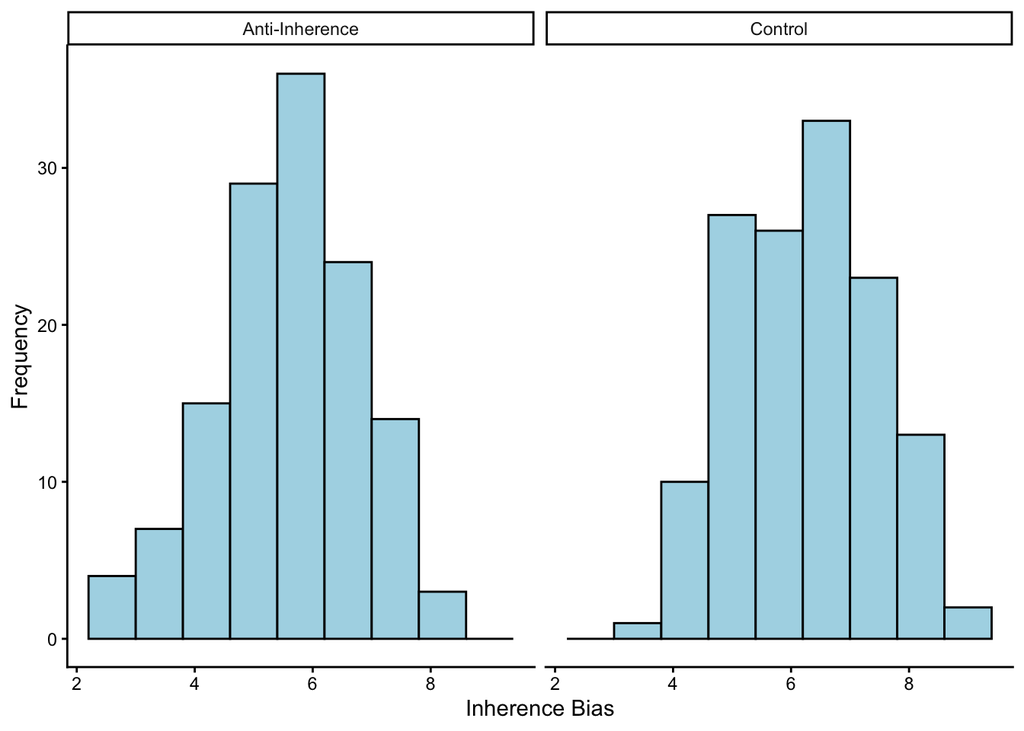

```
This is an untitled chart with no subtitle or caption.
The chart is comprised of 2 panels containing sub-charts, arranged horizontally.
The panels represent different values of Condition.
Each sub-chart has x-axis 'Inherence Bias' with labels 2, 4, 6 and 8.
Each sub-chart has y-axis 'Frequency' with labels 0, 10, 20 and 30.
Panel 1 represents data for Condition = Anti-Inherence COORD = 1.
Panel 1 is a bar chart with 9 vertical bars.
Bar 1 is centered at 2.6, and length is from 0 to 4.
Bar 2 is centered at 3.4, and length is from 0 to 7.
Bar 3 is centered at 4.2, and length is from 0 to 15.
Bar 4 is centered at 5, and length is from 0 to 29.
Bar 5 is centered at 5.8, and length is from 0 to 36.
Bar 6 is centered at 6.6, and length is from 0 to 24.
Bar 7 is centered at 7.4, and length is from 0 to 14.
Bar 8 is centered at 8.2, and length is from 0 to 3.
Bar 9 is centered at 9, and length is from 0 to 0.
It has colour set to black.
It has fill set to very light greenish blue.
Panel 2 represents data for Condition = Control COORD = 1.
Panel 2 is a bar chart with 9 vertical bars.
Bar 1 is centered at 2.6, and length is from 0 to 0.
Bar 2 is centered at 3.4, and length is from 0 to 1.
Bar 3 is centered at 4.2, and length is from 0 to 10.
Bar 4 is centered at 5, and length is from 0 to 27.
Bar 5 is centered at 5.8, and length is from 0 to 26.
Bar 6 is centered at 6.6, and length is from 0 to 33.
Bar 7 is centered at 7.4, and length is from 0 to 23.
Bar 8 is centered at 8.2, and length is from 0 to 13.
Bar 9 is centered at 9, and length is from 0 to 2.
It has colour set to black.
It has fill set to very light greenish blue.
```

```r
df %>%
    ggplot(aes(x = InherenceBias)) +
    facet_wrap(~Condition) +
    geom_histogram(bins = 9, color = "black", fill = "lightblue") +
    labs(x = "Inherence Bias", y = "Frequency") +
    theme_classic()
```

##### 1.3.3.1.1 Shapiro-Wilk Test: `shapiro.test()` from base R

There is a statistical test for normality called the Shapiro-Wilk test. The null hypothesis for the Shapiro-Wilk test is that the data are normally distributed. If the p-value is less than 0.05, we reject the null hypothesis and conclude that the data are not normally distributed. So here, what we are looking for is that “there is not enough evidence that the data are not normally distributed” – when p > .05, we proceed with the test.

```r
res_shapiro_a <- df %>%
  filter(Condition == "Control") %>%
  pull("InherenceBias") %>%
  shapiro.test()

res_shapiro_b <- df %>%
  filter(Condition == "Anti-Inherence") %>%
  pull("InherenceBias") %>%
  shapiro.test()
```

###### Control condition normality test

```r
res_shapiro_a %>%
  tidy() %>%
  mutate(
    across(where(is.numeric) & !p.value, ~ apa_num(.)),
    p.value = apa_p(p.value)
  ) %>%
  knitr::kable()
```

| statistic | p.value | method |
| --- | --- | --- |
| 0.99 | .294 | Shapiro-Wilk normality test |

###### Anti-Inherence condition normality test

```r
res_shapiro_b %>%
  tidy() %>%
  mutate(
    across(where(is.numeric) & !p.value, ~ apa_num(.)),
    p.value = apa_p(p.value)
  ) %>%
  knitr::kable()
```

| statistic | p.value | method |
| --- | --- | --- |
| 0.98 | .125 | Shapiro-Wilk normality test |

**NoteShapiro-Wilk Test Results**

- Control: *W* = 0.99, *p* = .294
- Anti-Inherence: *W* = 0.98, *p* = .125

There is not enough evidence that the data are not normally distributed, so the assumption of normality is met, and we are good to go with the t-test.

#### 1.3.3.2 Homogeneity of Variance

The fourth assumption is about the variance of the data: (4) the variance of the two groups are equal. We can check this assumption using Levene’s test, which tests the null hypothesis that the variances of the two groups are equal. If the p-value is less than 0.05, we reject the null hypothesis and conclude that the variances are not equal. So here, what we are looking for is that “there is not enough evidence that the variances are not equal” – when p > .05, we proceed with the test.

```r
res_levene <- leveneTest(InherenceBias ~ Condition, data = df, center = mean)
res_levene %>%
  tidy() %>%
  mutate(
    across(where(is.numeric) & !p.value, ~ apa_num(.)),
    p.value = apa_p(p.value)
  ) %>%
  knitr::kable()
```

| statistic | p.value | df | df.residual |
| --- | --- | --- | --- |
| 0.00 | .969 | 1 | 265 |

There is not enough evidence that the variances are not equal, so the assumption of homogeneity of variance is met, and we are good to go with the t-test.

**NoteLevene’s Test Results**

*F*(1, 265) = 0.00, *p* = .969

### 1.3.4 Descriptive Statistics

#### 1.3.4.1 Control Condition

```r
df %>% filter(Condition == "Control") %>%
  describe() %>%
  apa_num() %>% # round the numbers to 2 decimal places
  knitr::kable()
```

|  | vars | n | mean | sd | median | trimmed | mad | min | max | range | skew | kurtosis | se |
| --- | --- | --- | --- | --- | --- | --- | --- | --- | --- | --- | --- | --- | --- |
| InherenceBias | 1 | 135.00 | 6.28 | 1.18 | 6.40 | 6.27 | 1.28 | 3.13 | 9.00 | 5.87 | -0.04 | -0.63 | 0.10 |
| Condition* | 2 | 135.00 | 2.00 | 0.00 | 2.00 | 2.00 | 0.00 | 2.00 | 2.00 | 0.00 | NA | NA | 0.00 |

#### 1.3.4.2 Anti-Inherence Condition

```r
df %>% filter(Condition == "Anti-Inherence") %>%
  describe() %>%
  apa_num() %>% # round the numbers to 2 decimal places
  knitr::kable()
```

|  | vars | n | mean | sd | median | trimmed | mad | min | max | range | skew | kurtosis | se |
| --- | --- | --- | --- | --- | --- | --- | --- | --- | --- | --- | --- | --- | --- |
| InherenceBias | 1 | 132.00 | 5.64 | 1.23 | 5.67 | 5.69 | 1.28 | 2.60 | 8.20 | 5.60 | -0.32 | -0.21 | 0.11 |
| Condition* | 2 | 132.00 | 1.00 | 0.00 | 1.00 | 1.00 | 0.00 | 1.00 | 1.00 | 0.00 | NA | NA | 0.00 |

### 1.3.5 Bar graphs of the means and standard errors

For the indepedent samples t-test, we will plot a bar graph of the mean inherence bias scores and the standard errors of the mean for each condition. The error bars can represent either the standard error of the mean or the 95% confidence interval. You will need to report which one you are using. Here, we will use the standard error of the mean.

```
This is an untitled chart with no subtitle or caption.
It has x-axis 'Condition' with labels Anti-Inherence and Control.
It has y-axis 'Inherence Bias' with labels 0.0, 2.5, 5.0 and 7.5.
It has 3 layers.
Layer 1 is a bar chart with 2 vertical bars.
Bar 1 is centered at 1, and length is from 0 to 5.64.
Bar 2 is centered at 2, and length is from 0 to 6.28.
Layer 1 has fill set to very light greenish blue.
Layer 1 has colour set to black.
Layer 1 has width set to 0.5.
Layer 2 is an errorbar graph that VI cannot process.
Layer 2 has width set to 0.2.
Layer 3 is a set of 266 big solid circle points of which about 98% can be seen.
Layer 3 has alpha set to 0.2.
Layer 3 has size set to 0.5.
```

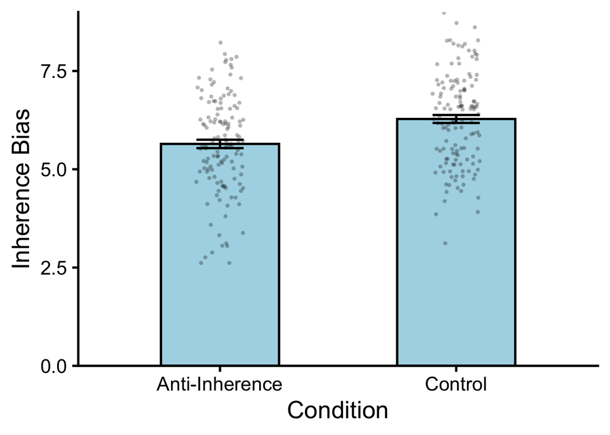

Figure 2: Bar graph of the mean inherence bias scores. Error bars represent the standard error of the mean.

```r
df %>%
  ggplot(aes(x = Condition, y = InherenceBias)) +
  # mean per condition
  stat_summary(fun = mean, geom = "bar", fill = "lightblue", color = "black", width = 0.5) +
  # standard error per condition
  stat_summary(fun.data = mean_se, geom = "errorbar", width = 0.2) +
  labs(x = "Condition", y = "Inherence Bias") +
  # add individual data points with jitter and transparency
  geom_point(position = position_jitter(width = 0.1), alpha = 0.2, size = 0.5) +
  # fix the horizontal axis at y = 0
  scale_y_continuous(expand = c(0, 0), limits = c(0, 9))
```

### 1.3.6 Independent Samples t-Test

To compute the independent samples t-test, we will use the `t.test()` function from base R. Because our the `InherenceBias` variable contains both conditions (Control and Anti-Inherence), we can mark that this DV should be compared across `Condition` using this formula: `Inherence Bias ~ Condition`. The general syntax is `dv ~ iv`, where `dv` is the dependent variable and `iv` is the independent variable.

The `data` argument specifies the data frame that contains the variables.

The `var.equal` argument specifies whether to assume equal variances or not. If `var.equal = TRUE`, the function will use the pooled variance to compute the t statistic. If `var.equal = FALSE`, the function will use Welch’s t-test, which does not assume equal variances. Because our Levene’s test was not significant, we can assume equal variances and set `var.equal = TRUE`.

The `alternative` argument specifies the alternative hypothesis. The default is “two.sided”, which tests for a difference in means in either direction. You can also specify “less” or “greater” to test for a difference in means in one direction.

```r
res_ind_t <- t.test(InherenceBias ~ Condition,
                  data = df,
                  var.equal = TRUE,
                  alternative = "two.sided")

res_ind_t %>%
  tidy() %>%
  mutate(
    across(where(is.numeric) & !p.value, ~ apa_num(.)),
    p.value = apa_p(p.value)
  ) %>%
  knitr::kable()
```

| estimate | estimate1 | estimate2 | statistic | p.value | parameter | conf.low | conf.high | method | alternative |
| --- | --- | --- | --- | --- | --- | --- | --- | --- | --- |
| -0.63 | 5.64 | 6.28 | -4.29 | < .001 | 265.00 | -0.92 | -0.34 | Two Sample t-test | two.sided |

```r
res_ind_t
```

```
    Two Sample t-test

data:  InherenceBias by Condition
t = -4.2939, df = 265, p-value = 2.465e-05
alternative hypothesis: true difference in means between group Anti-Inherence and group Control is not equal to 0
95 percent confidence interval:
 -0.9248076 -0.3433181
sample estimates:
mean in group Anti-Inherence        mean in group Control
                    5.644949                     6.279012
```

**NoteIndependent Samples t-test Results in APA format**

*Δ**M* = −0.63, 95% CI $[−0.92, −0.34]$, *t*(265) = −4.29, *p* < .001

### 1.3.7 Effect Size (Cohen’s d)

We will report the effect size using Cohen’s d. Again, we can use the same formula, and specify that the we can assume equal variances using the method argument by passing `pooled`. If we did not assume equal variances, we would use `method = "unequal"`.

```r
d_ind <- cohensD(InherenceBias ~ Condition, data = df, method = "pooled")
d_ind
```

```
[1] 0.5256036
```

**NoteCohen’s d**

- Equal variance: Cohen’s d = 0.53

### 1.3.8 Write up the results

> A independent-samples t-test was performed to compare inherence bias scores between the Anti-Inherence and Control conditions. The results indicated that the mean inherence bias score was significantly reduced in the Anti-Inherence condition (*M*<sub>Anti-Inherence</sub> = 5.64, *S**D*<sub>Anti-Inherence</sub> = 1.23) than in the Control condition (*M*<sub>Control</sub> = 6.28, *S**D*<sub>Control</sub> = 1.18), *Δ**M* = −0.63, 95% CI $[−0.92, −0.34]$, *t*(265) = −4.29, *p* < .001, with a moderate effect size, d = 0.53 (see Figure 2). These results suggest that priming extrinsic explanations can reduce inherence bias.

**TipIndependent Samples t-test Write-Up Checklist**

- What type of test was performed (e.g., Student’s t-test, Welch’s t-test), to test what hypothesis?
- Which DV was tested?
- What was your sample mean and standard deviation in each group/condition?
  - *M*<sub>1</sub>, *S**D*<sub>1</sub>
  - *M*<sub>2</sub>, *S**D*<sub>2</sub>
- What was your estimate for the difference in means between the two groups/conditions?
  - *M*<sub>1</sub> − *M*<sub>2</sub>
  - 95% CI<sub>*M*<sub>1</sub> − *M*<sub>2</sub></sub>
- What are the results of the analysis?
  - Was the mean of one group significantly higher or lower than the other group? In which direction?
  - t statistic
  - degrees of freedom
  - p-value
- What was the practical significance of the results?
  - Small, medium, or large effect size?
  - Cohen’s d
- What do the statistical results mean in the context of the research question?
- If a figure is included, refer to it in the write up.

## 1.4 Exercises

**TipExercise: Imundo et al. (2021) Study 2**

`imundo_study2.csv` contains data for the restudy condition of Imundo et al. (2021) Study 2. Conduct an appropriate t-test for the data, comparing the Same vs. Different context conditions.

- `ID`: participant ID
- `StudyActivity`: For this lab, there is only “Restudy” activity included in the data.
- `RestudyContext`: the condition that participants were assigned to, either “Same” or “Different”
- `ProportionRecalled`: the proportion of items that participants correctly recalled in the final test. This is the dependent variable that we will be testing.
- `NumberCorrectWordsRecalled`: the number of items that participants correctly recalled in the final test.
- `Age`: the age of the participant
- `Gender`: the gender of the participant; “Female” or “Male”

To get you started, the following code reads in the data and cleans it up for analysis. You can use this code as a starting point for your analysis.

```r
df <- read_csv('data/imundo_study2.csv') %>%
  as_tibble() %>%
  mutate(RestudyContext = factor(RestudyContext, levels = c("Different", "Same")))
```

1. Plot the data using a bar graph with error bars representing the standard error of the mean. You can use the code above as a template for your graph.
2. Run the appropriate t-test, and report the results in APA style, interpreting the results in the context of the research question.

## References

Tworek, Christina M., and Andrei Cimpian. 2016. “Why Do People Tend to Infer ‘Ought’ From ‘Is’? The Role of Biases in Explanation.” *Psychological Science* 27 (8): 1109–22. https://doi.org/10.1177/0956797616650875.